# analysis

#load packages and data

```r
library(ggplot2) #for plotting
library(broom) #for cleaning up output from lm()
library(here) #for data loading/saving
library(tidymodels) #for modeling
library(gridExtra) #for exporting tables
library(gridExtra) #for savings images in grids

data <- readRDS(here("data", "processed_data", "mpwrfcombo.rds"))
```

# fit linear model to continuous outcome (particles_l)

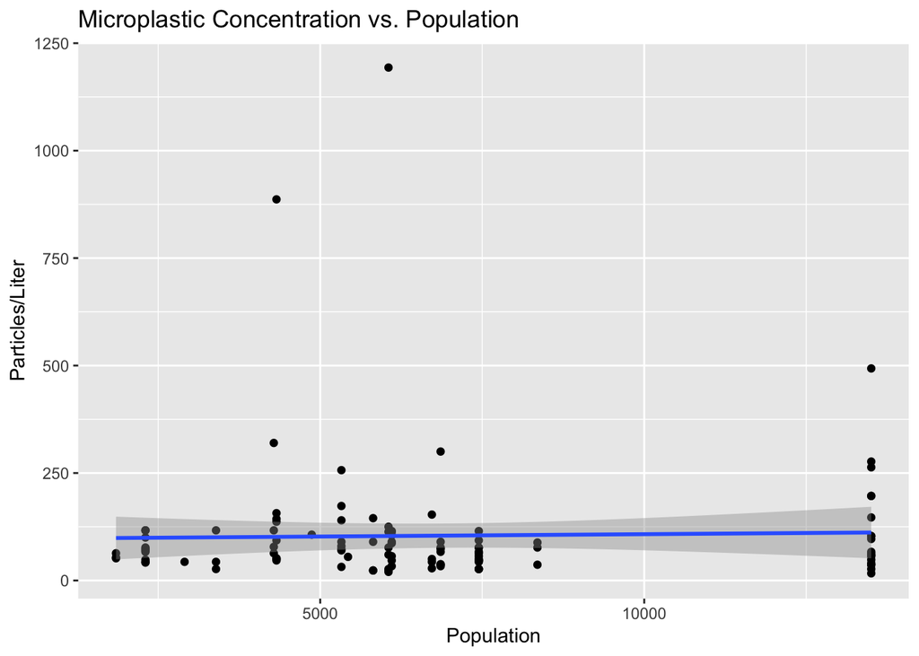

```r
#attempt to visualize data
#look at particles per L vs population
m1 <- ggplot(data, aes(x = population, y = particles_l)) + geom_point() + geom_smooth(method = lm) + labs(title = "Microplastic Concentration vs. Population", x = "Population", y = "Particles/Liter")

plot(m1)
```

```r
#save figure
ggsave(filename = here("results","m_concvpop.png"), plot=m1)
```

# particles per liter vs population with outliers filtered out

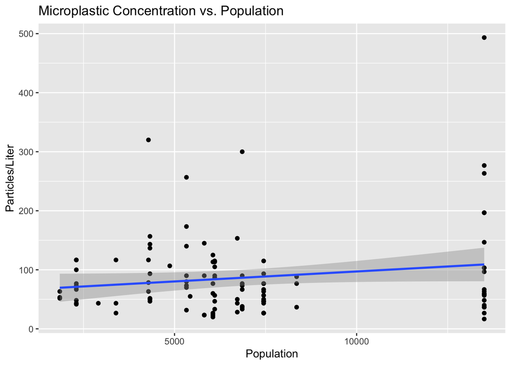

```r
#attempt to visualize data
#look at particles per L vs population
m2 <- data %>% filter(particles_l < 750) %>% ggplot(aes(x = population, y = particles_l)) + geom_point() + geom_smooth(method = lm) + labs(title = "Microplastic Concentration vs. Population", x = "Population", y = "Particles/Liter")

plot(m2)
```

```r
#save figure
ggsave(filename = here("results","m_concvpop_no_outlier.png"), plot=m2)
```

# fit linear model to continuous outcome (particles_l) with log transformation

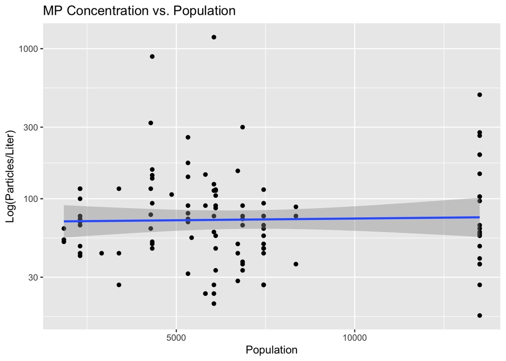

```r
#attempt to visualize data
#look at particles per L vs population
m3 <- ggplot(data, aes(x = population, y = particles_l)) + geom_point() +
  scale_y_continuous(trans='log10') + geom_smooth(method = lm) + labs(title = "MP Concentration vs. Population", x = "Population", y = "Log(Particles/Liter)")

plot(m3)
```

```r
#save figure
ggsave(filename = here("results","m_logconcvpop.png"), plot=m3)
```

# visualize particles vs e.coli.cfu

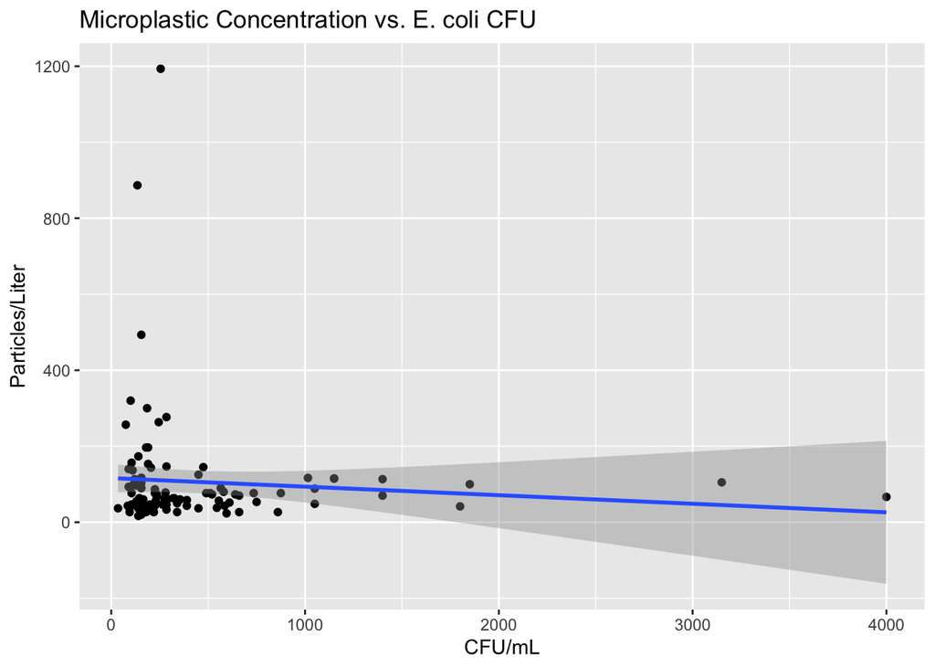

```r
m4 <- ggplot(data, aes(x = e.coli.cfu, y = particles_l)) + geom_point() + geom_smooth(method = lm) + labs(title = "Microplastic Concentration vs. E. coli CFU", x = "CFU/mL", y = "Particles/Liter")

plot(m4)
```

```r
#save figure
ggsave(filename = here("results","m_concvcfu.png"), plot=m4)
```

# particles per liter vs e.coli.cfu with log transformation

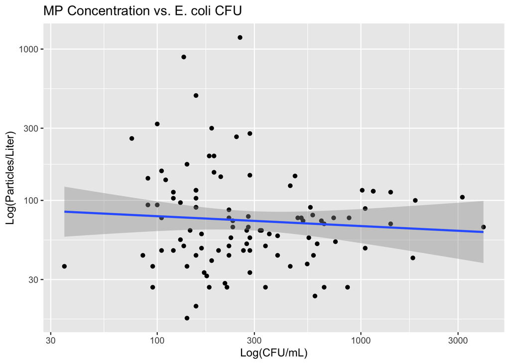

```r
m5 <- ggplot(data, aes(x = e.coli.cfu, y = particles_l)) + geom_point() + scale_x_continuous(trans='log10') +
  scale_y_continuous(trans='log10') + geom_smooth(method = lm) + labs(title = "MP Concentration vs. E. coli CFU", x = "Log(CFU/mL)", y = "Log(Particles/Liter)")

plot(m5)
```

```r
#save figure
ggsave(filename = here("results","m_logconcvcfu.png"), plot=m5)
```

# linear regression

```r
data <- data %>% select("particles_l", "visual_score", "turbidity.ntu", "temperature.c", "e.coli.cfu", "population", "dist", "watershed")
#save data subset
saveRDS(data, file = here("data", "processed_data", "data_subset.rds"))
#linear regression model specification set up
lm_mod <- linear_reg() %>% set_engine("lm")
#estimating/training linear model
lm_fit1 <- lm_mod %>% fit(particles_l ~ ., data = data)
#save table
lm_fit1_table <- tidy(lm_fit1)
#view summary of fit
(lm_fit1)
```

```
## parsnip model object
##
## Fit time:  4ms
##
## Call:
## stats::lm(formula = particles_l ~ ., data = data)
##
## Coefficients:
##                  (Intercept)                  visual_score
##                   -85.415552                      3.150197
##                turbidity.ntu                 temperature.c
##                     8.184926                     -0.915353
##                   e.coli.cfu                    population
##                    -0.026984                     -0.001919
##                         dist           watershedBear Creek
##                     0.003350                    -96.760206
##      watershedBrooklyn Creek          watershedCalls Creek
##                    -4.784536                    -17.226307
##     watershedHunnicutt Creek         watershedMcNutt Creek
##                    67.113845                     -5.329244
## watershedMiddle Oconee River   watershedNorth Oconee River
##                   -49.371845                    104.253925
##        watershedOconee River          watershedSandy Creek
##                    -0.765456                    -60.185064
##       watershedTanyard Creek          watershedTrail Creek
##                    77.619620                     13.025621
```

```r
#save file
saveRDS(lm_fit1_table, file = here("results", "lm_fit_table.rds"))
```

# linear regression for one predictor, one outcome

```r
#predict particles per liter based on population
lm_fit2 <- lm_mod %>% fit(particles_l ~ population, data = data)
#view summary of fit
tidy(lm_fit2)
```

```
## # A tibble: 2 × 5
##   term        estimate std.error statistic p.value
##   <chr>          <dbl>     <dbl>     <dbl>   <dbl>
## 1 (Intercept) 96.8      31.5         3.07  0.00270
## 2 population   0.00109   0.00406     0.270 0.788
```

```r
#predict particles per liter based on e coli
lm_fit3 <- lm_mod %>% fit(particles_l ~ e.coli.cfu, data = data)
#view summary of fit
tidy(lm_fit3)
```

```
## # A tibble: 2 × 5
##   term        estimate std.error statistic      p.value
##   <chr>          <dbl>     <dbl>     <dbl>        <dbl>
## 1 (Intercept) 116.       18.9        6.15  0.0000000155
## 2 e.coli.cfu   -0.0225    0.0263    -0.856 0.394
```

```r
#comparison of fit
#comp2_3 <- anova(lm_fit2$fit, lm_fit3$fit, test = "Chisq")
#comp2_3
#these lines of code are kept to show how I got the original error message about models not being fitted to the same size dataset, but I have cut them out so that the code will run smoothly
```

Here, we get an error message that models were not fitted to the same size of dataset. This is likely due to missing values in some predictors. To solve this, we can clean up the dataset some more and create a dataset specifically to use for modelling, that has only predictors of interest and no missing values.

# create subset of data with only complete cases

```r
data %>% is.na() %>% summary() #check out missing cases
```

```
##  particles_l     visual_score    turbidity.ntu   temperature.c
##  Mode :logical   Mode :logical   Mode :logical   Mode :logical
##  FALSE:109       FALSE:99        FALSE:104       FALSE:101
##                  TRUE :10        TRUE :5         TRUE :8
##  e.coli.cfu      population         dist         watershed
##  Mode :logical   Mode :logical   Mode :logical   Mode :logical
##  FALSE:103       FALSE:109       FALSE:109       FALSE:109
##  TRUE :6
```

```r
complete <- data %>% na.omit() #save complete cases
```

Let’s try the code from above again with the complete dataset

# Modeling with complete cases only

```r
#estimating/training linear model
lm_fit4 <- lm_mod %>% fit(particles_l ~ ., data = complete)
#view summary of fit
tidy(lm_fit4)
```

```
## # A tibble: 18 × 5
##    term                          estimate std.error statistic p.value
##    <chr>                            <dbl>     <dbl>     <dbl>   <dbl>
##  1 (Intercept)                  -85.4     200.       -0.427     0.671
##  2 visual_score                   3.15      3.55      0.887     0.378
##  3 turbidity.ntu                  8.18      5.20      1.57      0.120
##  4 temperature.c                 -0.915     3.78     -0.242     0.809
##  5 e.coli.cfu                    -0.0270    0.0353   -0.765     0.447
##  6 population                    -0.00192   0.0109   -0.177     0.860
##  7 dist                           0.00335   0.00798   0.420     0.676
##  8 watershedBear Creek          -96.8     210.       -0.460     0.647
##  9 watershedBrooklyn Creek       -4.78    141.       -0.0340    0.973
## 10 watershedCalls Creek         -17.2      97.7      -0.176     0.861
## 11 watershedHunnicutt Creek      67.1     116.        0.580     0.564
## 12 watershedMcNutt Creek         -5.33     87.4      -0.0610    0.952
## 13 watershedMiddle Oconee River -49.4     114.       -0.433     0.666
## 14 watershedNorth Oconee River  104.      116.        0.898     0.372
## 15 watershedOconee River         -0.765   138.       -0.00555   0.996
## 16 watershedSandy Creek         -60.2     203.       -0.296     0.768
## 17 watershedTanyard Creek        77.6     158.        0.491     0.625
## 18 watershedTrail Creek          13.0     132.        0.0985    0.922
```

```r
#predict particles per liter based on population
lm_fit5 <- lm_mod %>% fit(particles_l ~ population, data = complete)
#view summary of fit
tidy(lm_fit5)
```

```
## # A tibble: 2 × 5
##   term          estimate std.error statistic p.value
##   <chr>            <dbl>     <dbl>     <dbl>   <dbl>
## 1 (Intercept) 107.        37.5        2.84   0.00551
## 2 population    0.000478   0.00482    0.0992 0.921
```

```r
#predict particles per liter based on e coli
lm_fit6 <- lm_mod %>% fit(particles_l ~ e.coli.cfu, data = complete)
#view summary of fit
tidy(lm_fit6)
```

```
## # A tibble: 2 × 5
##   term        estimate std.error statistic     p.value
##   <chr>          <dbl>     <dbl>     <dbl>       <dbl>
## 1 (Intercept) 122.       21.1        5.77  0.000000111
## 2 e.coli.cfu   -0.0253    0.0279    -0.906 0.368
```

```r
#comparison of fit
comp5_6 <- anova(lm_fit5$fit, lm_fit6$fit, test = "Chisq")
comp5_6
```

```
## Analysis of Variance Table
##
## Model 1: particles_l ~ population
## Model 2: particles_l ~ e.coli.cfu
##   Res.Df     RSS Df Sum of Sq Pr(>Chi)
## 1     90 2318519
## 2     90 2297835  0     20684
```

# Modeling single predictors with complete cases

```r
#predict particles per liter based on population
lm_fit8 <- lm_mod %>% fit(particles_l ~ population, data = complete)
#view summary of fit
tidy(lm_fit8)
```

```
## # A tibble: 2 × 5
##   term          estimate std.error statistic p.value
##   <chr>            <dbl>     <dbl>     <dbl>   <dbl>
## 1 (Intercept) 107.        37.5        2.84   0.00551
## 2 population    0.000478   0.00482    0.0992 0.921
```

```r
#predict particles per liter based on e coli
lm_fit9 <- lm_mod %>% fit(particles_l ~ e.coli.cfu, data = complete)
#view summary of fit
tidy(lm_fit9)
```

```
## # A tibble: 2 × 5
##   term        estimate std.error statistic     p.value
##   <chr>          <dbl>     <dbl>     <dbl>       <dbl>
## 1 (Intercept) 122.       21.1        5.77  0.000000111
## 2 e.coli.cfu   -0.0253    0.0279    -0.906 0.368
```

```r
#model comparison
comp8_9 <- anova(lm_fit8$fit, lm_fit9$fit, test = "Chisq")
comp8_9
```

```
## Analysis of Variance Table
##
## Model 1: particles_l ~ population
## Model 2: particles_l ~ e.coli.cfu
##   Res.Df     RSS Df Sum of Sq Pr(>Chi)
## 1     90 2318519
## 2     90 2297835  0     20684
```

# model evaluation, splitting data into train and test

```r
#split into test and train
#set seed for reproducible analysis
set.seed(222)
#subset 3/4 of data as training set
data_split <- initial_split(data, prop = 3/4)

#save sets as data frames
train_data <- training(data_split)
test_data <- testing(data_split)
```

# recipe to fit particles/L outcome to all predictors

```r
#recipe for particles per liter, all predictors
mp_rec <-
  recipe(particles_l ~ ., data = train_data)

#linear regression model workflow set up
mp_wflow <-
  workflow() %>% add_model(lm_mod) %>% add_recipe(mp_rec)

#use workflow to prepare recipe and train model with predictors
mp_fit <-
  mp_wflow %>% fit(data = train_data)

#extract model coefficient
mp_fit %>% extract_fit_parsnip() %>% tidy()
```

```
## # A tibble: 18 × 5
##    term                            estimate std.error statistic p.value
##    <chr>                              <dbl>     <dbl>     <dbl>   <dbl>
##  1 (Intercept)                  -202.        273.      -0.741     0.462
##  2 visual_score                    3.99        4.63     0.862     0.393
##  3 turbidity.ntu                   7.56        6.87     1.10      0.277
##  4 temperature.c                   1.01        5.93     0.170     0.866
##  5 e.coli.cfu                     -0.0820      0.0968  -0.847     0.401
##  6 population                     -0.000111    0.0149  -0.00750   0.994
##  7 dist                            0.00480     0.0108   0.445     0.658
##  8 watershedBear Creek           -65.1       265.      -0.245     0.807
##  9 watershedBrooklyn Creek        95.2       201.       0.474     0.638
## 10 watershedCalls Creek           54.9       137.       0.401     0.690
## 11 watershedHunnicutt Creek      141.        159.       0.887     0.379
## 12 watershedMcNutt Creek          39.5       124.       0.318     0.752
## 13 watershedMiddle Oconee River   -3.80      156.      -0.0244    0.981
## 14 watershedNorth Oconee River   161.        158.       1.02      0.313
## 15 watershedOconee River         145.        200.       0.727     0.470
## 16 watershedSandy Creek          -44.7       259.      -0.172     0.864
## 17 watershedTanyard Creek        155.        208.       0.743     0.461
## 18 watershedTrail Creek          118.        206.       0.572     0.570
```

# evaluate model with RMSE

```r
#use trained workflow to predict with test data
predict(mp_fit, test_data)
```

```
## # A tibble: 28 × 1
##    .pred
##    <dbl>
##  1 142.
##  2  63.4
##  3  54.2
##  4  51.6
##  5  81.7
##  6  NA
##  7  98.0
##  8  84.2
##  9 186.
## 10 168.
## # … with 18 more rows
```

```r
#include probabilities
mp_aug <- augment(mp_fit, test_data)

#get RMSE for test data
mp_aug %>% rmse(truth = particles_l, .pred)
```

```
## # A tibble: 1 × 3
##   .metric .estimator .estimate
##   <chr>   <chr>          <dbl>
## 1 rmse    standard        101.
```

#trying model evaluation with turbidity - linear regression

```r
#estimating/training linear model
turb_fit1 <- lm_mod %>% fit(particles_l ~ turbidity.ntu, data = data)
#view summary of fit
tidy(turb_fit1)
```

```
## # A tibble: 2 × 5
##   term          estimate std.error statistic p.value
##   <chr>            <dbl>     <dbl>     <dbl>   <dbl>
## 1 (Intercept)      61.3      29.4       2.09  0.0392
## 2 turbidity.ntu     5.10      2.90      1.76  0.0814
```

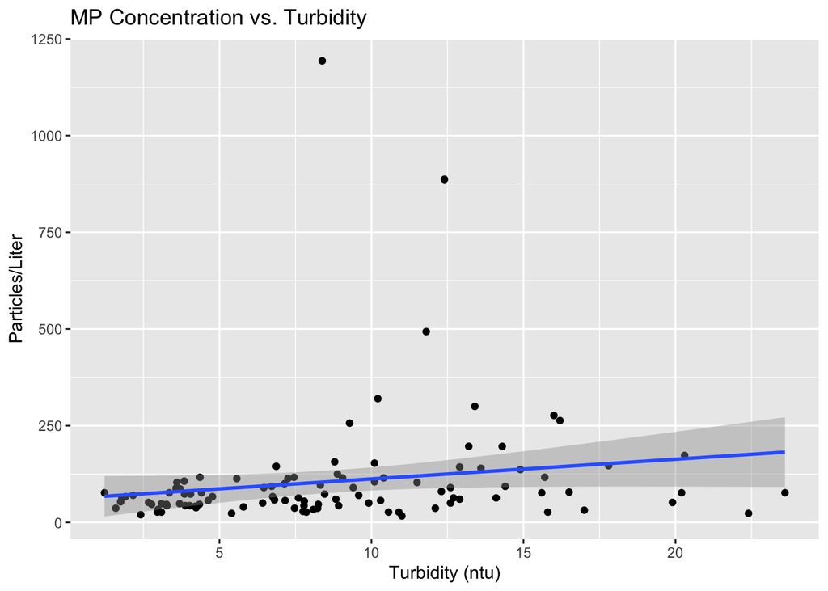

```r
#visualize linear model
t1 <- ggplot(data, aes(x = turbidity.ntu, y = particles_l)) + geom_point() + geom_smooth(method = lm) + labs(title = "MP Concentration vs. Turbidity", x = "Turbidity (ntu)", y = "Particles/Liter")
t1
```

```r
#save figure
ggsave(filename = here("results","m_concvturbidity.png"), plot=t1)
```

#evaluating fit using turbidity as predictor

```r
#recipe for particles per liter, all predictors
turb_rec <-
  recipe(particles_l ~ turbidity.ntu, data = train_data)

#linear regression model workflow set up
turb_wflow <-
  workflow() %>% add_model(lm_mod) %>% add_recipe(turb_rec)

#use workflow to prepare recipe and train model with predictors
turb_fit <-
  turb_wflow %>% fit(data = train_data)

#extract model coefficient
turb_fit %>% extract_fit_parsnip() %>% tidy()
```

```
## # A tibble: 2 × 5
##   term          estimate std.error statistic p.value
##   <chr>            <dbl>     <dbl>     <dbl>   <dbl>
## 1 (Intercept)      70.9      38.2       1.86  0.0674
## 2 turbidity.ntu     4.68      3.80      1.23  0.222
```

```r
#use trained workflow to predict with test data
predict(turb_fit, test_data)
```

```
## # A tibble: 28 × 1
##    .pred
##    <dbl>
##  1 146.
##  2 117.
##  3 104.
##  4 106.
##  5 141.
##  6 108.
##  7 110.
##  8  81.0
##  9 112.
## 10  84.8
## # … with 18 more rows
```

```r
#include probabilities
turb_aug <- augment(turb_fit, test_data)

#get RMSE for test data
turb_aug %>% rmse(truth = particles_l, .pred)
```

```
## # A tibble: 1 × 3
##   .metric .estimator .estimate
##   <chr>   <chr>          <dbl>
## 1 rmse    standard        58.3
```

Here, we see that a model with turbidity as the single predictor produces an RMSE of 58. This is significantly better than the full, all-predictor model which had an RMSE of 101.

Going forward, perhaps we could add in additional predictors one at a time to determine what predictors may improve the model performance.

# linear model for distance from WRF

```r
#estimating/training linear model
wrf_fit1 <- lm_mod %>% fit(particles_l ~ dist, data = data)
#view summary of fit
tidy(wrf_fit1)
```

```
## # A tibble: 2 × 5
##   term         estimate std.error statistic p.value
##   <chr>           <dbl>     <dbl>     <dbl>   <dbl>
## 1 (Intercept) 96.5       29.9         3.23  0.00167
## 2 dist         0.000916   0.00305     0.300 0.765
```

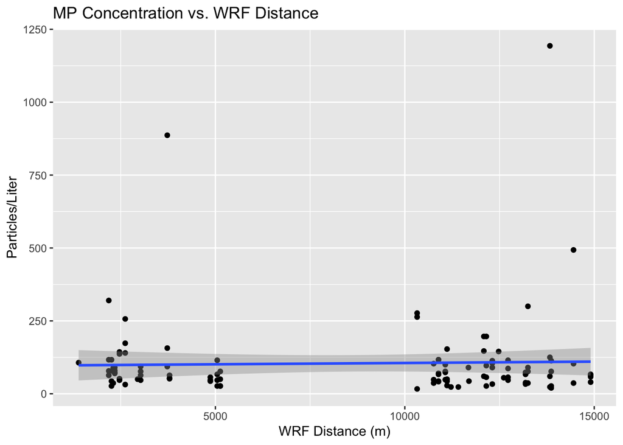

```r
#visualize linear model
wrf1 <- ggplot(data, aes(x = dist, y = particles_l)) + geom_point() + geom_smooth(method = lm) + labs(title = "MP Concentration vs. WRF Distance", x = "WRF Distance (m)", y = "Particles/Liter")
wrf1
```

```r
#save figure
ggsave(filename = here("results","m_concvwrfdist.png"), plot=wrf1)
```

# save grid image of results

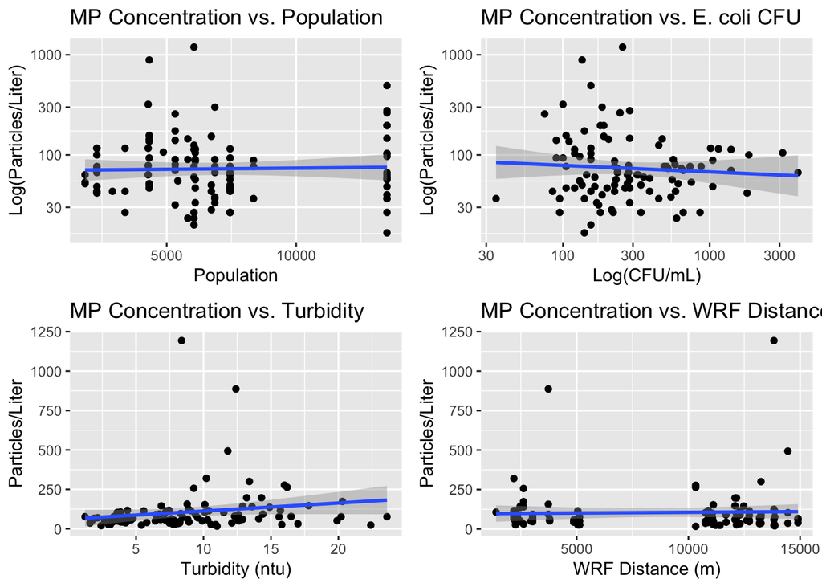

```r
# arrange grid with population, e coli, WRF, and turbidity predictive models
bivar_grid <- grid.arrange(m3, m5, t1, wrf1, ncol = 2)
```

```r
# save and export image
ggsave(bivar_grid, filename = here("results", "bivar_grid.png"))
```